# Práctica Final - Nuevas tendencias en minería de datos

Alumna: Maria Lucia Guastoni

15/5/2021

# 1. Introducción

En el presente trabajo se busca clasificar, mediante la implementación de redes neuronales, si un cliente suscribirá un depósito a plazo o no.

Los datos utilizados provienen de una campaña de marketing directa llevada a cabo por una institución bancaria portuguesa, consistente en llamadas telefónicas.

El dataset contiene 45.211 observaciones y 17 variables, de las cuales una de ellas corresponde a la variable target, que indica si la persona se ha suscrito a un depósito a plazo o no. A su vez, las variables explicativas pueden agruparse en tres categorías: datos bancarios de la persona, datos relacionados con el último contacto de la campaña actual, y otros atributos:

1 - age

2 - job : type of job (categorical: “admin.”, “unknown”, “unemployed”, “management”, “housemaid”, “entrepreneur”, “student”, “blue-collar”, “self-employed”, “retired”, “technician”, “services”)

3 - marital : marital status (categorical: “married”,“divorced”,“single”; note: “divorced” means divorced or widowed)

4 - education (categorical: “unknown”,“secondary”,“primary”,“tertiary”)

5 - default: has credit in default? (binary: “yes”,“no”)

6 - balance: average yearly balance, in euros (numeric)

7 - housing: has housing loan? (binary: “yes”,“no”)

8 - loan: has personal loan? (binary: “yes”,“no”)

Related with the last contact of the current campaign:

9 - contact: contact communication type (categorical:

“unknown”,“telephone”,“cellular”)

10 - day: last contact day of the month (numeric)

11 - month: last contact month of year (categorical: “jan”, “feb”, “mar”, …, “nov”, “dec”)

12 - duration: last contact duration, in seconds (numeric)

Other attributes:

13 - campaign: number of contacts performed during this campaign and for this client (numeric, includes last contact)

14 - pdays: number of days that passed by after the client was last contacted from a previous campaign (numeric, -1 means client was not previously contacted)

15 - previous: number of contacts performed before this campaign and for this client (numeric)

16 - poutcome: outcome of the previous marketing campaign (categorical: “unknown”,“other”,“failure”,“success”)

Output variable (desired target):

17 - y: has the client subscribed a term deposit? (binary: “yes”,“no”)

El trabajo está estructurado en 6 secciones. La presente, en donde se introduce y describe el problema. La segunda, en donde se cargan y limpian los datos. Una tercera sección en la que se realiza un análisis exploratorio de los datos, la cuarta en donde se preprocesan los datos para poder a continuación, en la sección cinco, evaluar diferentes modelos de redes neuronales, y finalmente elegir el mejor entre todos.

# 2. Carga y limpieza de los datos

Los datos pueden encontrarse en el siguiente enlace:

https://projet.liris.cnrs.fr/ccc/

Dado el formato xml, se han cargado los datos y se les ha dado formato csv en el script de python: `carga_limpieza_datos`.

Una vez convertidos a csv, se leen los datos:

```
  age          job marital education default balance housing loan contact day
1  58   management married  tertiary      no    2143     yes   no unknown   5
2  44   technician  single secondary      no      29     yes   no unknown   5
3  33 entrepreneur married secondary      no       2     yes  yes unknown   5
4  47  blue-collar married   unknown      no    1506     yes   no unknown   5
5  33      unknown  single   unknown      no       1      no   no unknown   5
6  35   management married  tertiary      no     231     yes   no unknown   5
  month duration campaign pdays previous poutcome  y
1   may      261        1    -1        0  unknown no
2   may      151        1    -1        0  unknown no
3   may       76        1    -1        0  unknown no
4   may       92        1    -1        0  unknown no
5   may      198        1    -1        0  unknown no
6   may      139        1    -1        0  unknown no
```

Puede verse a simple vista que muchas observaciones son “unknown”, es decir, no hay información. Por lo tanto, son convertidas en “NA”.

Luego, se analiza, para las variables de tipo character, cuáles son sus valores únicos; y para las variables númericas, su distribución:

Variables tipo character:

```
$job
 [1] "management"    "technician"    "entrepreneur"  "blue-collar"
 [5] NA              "retired"       "admin."        "services"
 [9] "self-employed" "unemployed"    "housemaid"     "student"

$marital
[1] "married"  "single"   "divorced"

$education
[1] "tertiary"  "secondary" NA          "primary"

$default
[1] "no"  "yes"

$housing
[1] "yes" "no"

$loan
[1] "no"  "yes"

$contact
[1] NA          "cellular"  "telephone"

$month
 [1] "may" "jun" "jul" "aug" "oct" "nov" "dec" "jan" "feb" "mar" "apr" "sep"

$poutcome
[1] NA        "failure" "other"   "success"

$y
[1] "no"  "yes"
```

Variables numéricas:

```
$age
   Min. 1st Qu.  Median    Mean 3rd Qu.    Max.
  18.00   33.00   39.00   40.94   48.00   95.00

$balance
   Min. 1st Qu.  Median    Mean 3rd Qu.    Max.
  -8019      72     448    1362    1428  102127

$day
   Min. 1st Qu.  Median    Mean 3rd Qu.    Max.
   1.00    8.00   16.00   15.81   21.00   31.00

$duration
   Min. 1st Qu.  Median    Mean 3rd Qu.    Max.
    0.0   103.0   180.0   258.2   319.0  4918.0

$campaign
   Min. 1st Qu.  Median    Mean 3rd Qu.    Max.
  1.000   1.000   2.000   2.764   3.000  63.000

$pdays
   Min. 1st Qu.  Median    Mean 3rd Qu.    Max.
   -1.0    -1.0    -1.0    40.2    -1.0   871.0

$previous
    Min.  1st Qu.   Median     Mean  3rd Qu.     Max.
  0.0000   0.0000   0.0000   0.5803   0.0000 275.0000
```

En cuanto a la variable target, la distribución de sus clases es:

```
  no  yes
0.88 0.12
```

## Valores faltantes

Se examina la cantidad de valores nulos que tiene cada variable:

```
      age       job   marital education   default   balance   housing      loan
        0       288         0      1857         0         0         0         0
  contact       day     month  duration  campaign     pdays  previous  poutcome
    13020         0         0         0         0         0         0     36959
        y
        0
```

Dado que la variable “contact” posee muchos valores nulos (un 28.8% del total de observaciones), se elimina esta variable, asi como la variable “poutcome”, que tiene un 81.75 de valores faltantes.

También se eliminan variables que no aportan información relevante al análisis que se llevará a cabo: “contact”, “day”, “month”, “pdays” y “poutcome”.

Puede verse que las variables “job” y “education” tienen valores faltantes. Las observaciones con valores faltantes en ambas variables son:

```
[1] 127
```

Por tanto, hay en total 2018 observaciones con valores nulos en alguna de las dos variables.

Sin embargo, el tratamiento de estos valores se realizará más adelante, en la sección 3.3, utilizando el paquete `mice`, luego de haber identificado valores extremos.

# 3. Análisis exploratorio

## 3.1 Correlación

```
                  age     balance     duration     campaign     previous
age       1.000000000  0.09778274 -0.004648428  0.004760312  0.001288319
balance   0.097782739  1.00000000  0.021560380 -0.014578279  0.016673637
duration -0.004648428  0.02156038  1.000000000 -0.084569503  0.001203057
campaign  0.004760312 -0.01457828 -0.084569503  1.000000000 -0.032855290
previous  0.001288319  0.01667364  0.001203057 -0.032855290  1.000000000
```

Puede observarse que no existe correlación entre las variables numéricas.

## 3.2 Valores extremos

### 3.2.1 Identificación de valores extremos

En este apartado se analiza si existen valores muy alejados del valor medio de cada variable, es decir, valores extremos o outliers. Para ello, subdivide en análisis en dos, en función del tipo de variable que se trate: variables numéricas y variables tipo character.

#### 3.2.1.1 Variables numéricas

A continuación se visualiza, mediante boxplots, la distribución de cada una de las variables numéricas, y se determina la presencia de outliers.

#### Variable “age”

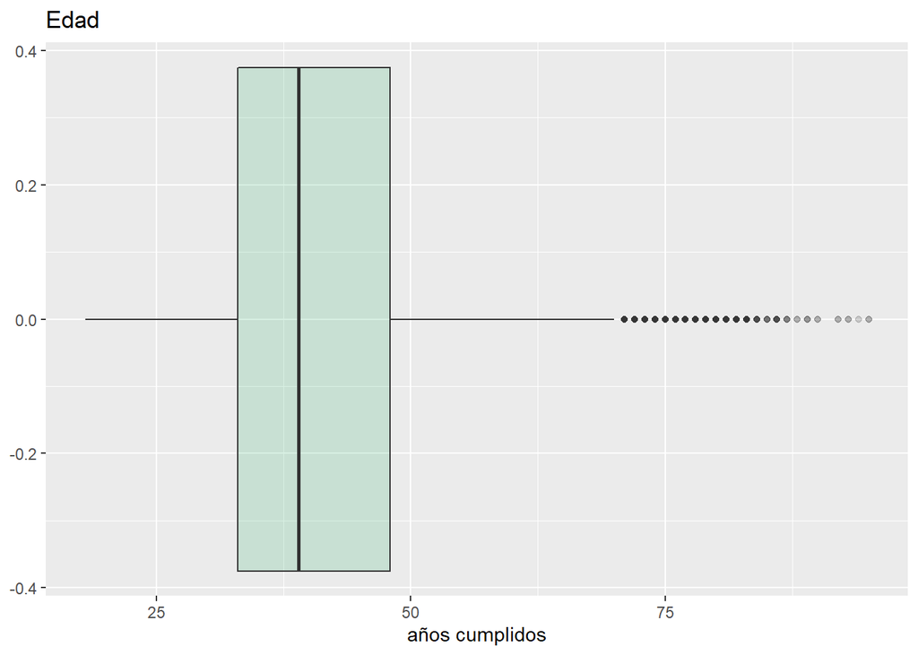

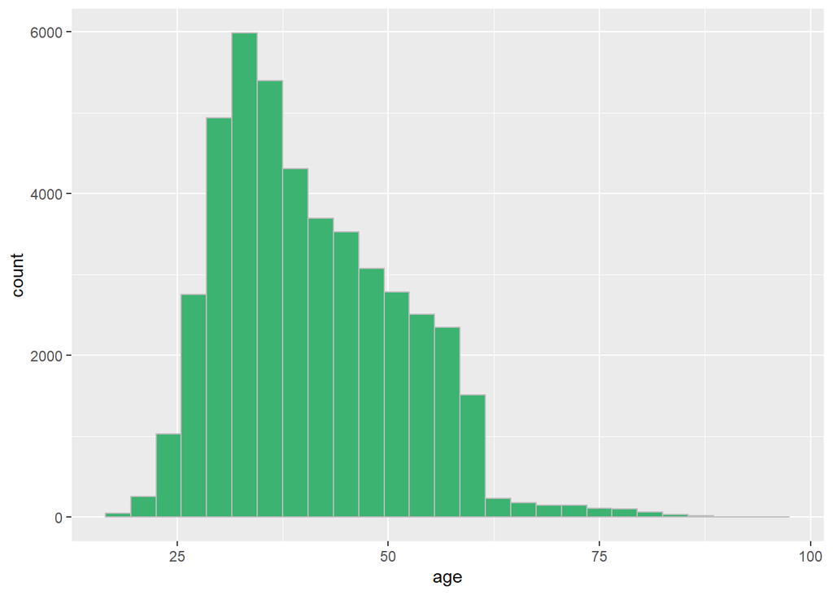

Los gráficos muestran que la variable “age” tiene outliers en la cola superior de la distribución.

A continuación se calculan los outliers, considerando como tal aquellos valores que están 1.5 veces por encima y debajo del rango intercuartílico de la variable, es decir:

outlier = Q3 + (Q3 - Q1) * 1.5

outlier = Q1 - (Q3 - Q1) * 1.5

```
Límite superior:  70.5
```

```
Porcentaje de observaciones por encima del límite superior:  0.96
```

```
Distribución de la cantidad de observaciones para edad superior a 71:
```

```
72 73 74 75 76 77 78 79 80 81 82 83 84 85 86 87 88 89 90 92 93 94 95
52 44 37 39 32 44 30 25 31 17 19 22  9  5  9  4  2  3  2  2  2  1  2
```

Se computarán estos valores extremos como “NA”, para luego estimar su valor.

```
Cantidad de valores NA de la variable age:  433
```

#### Variable “balance”

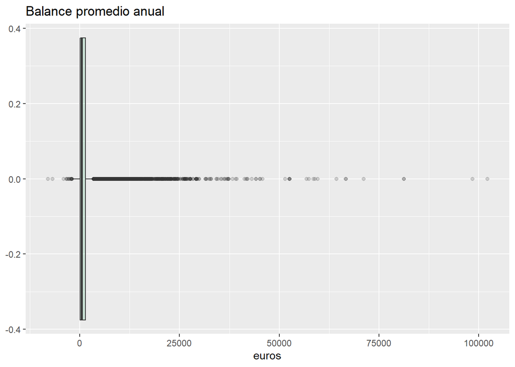

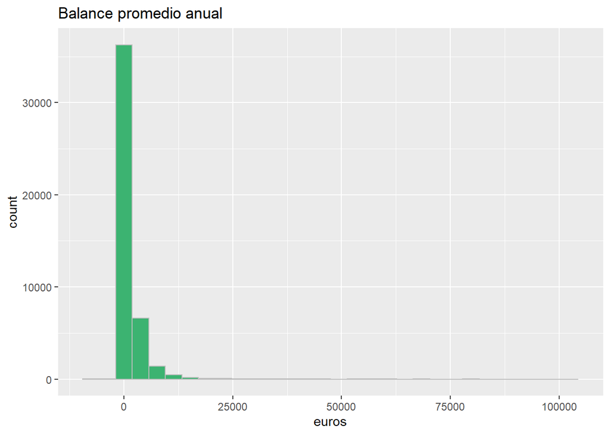

Esta variable está muy concentrada en valores en torno a 0. Los limites superior e inferior para determinar valores extremos son:

```
Límite superior:  3462
```

```
Límite inferior:  -1962
```

```
Porcentaje de observaciones por encima del límite superior:  10.56
```

```
Porcentaje de observaciones por debajo del límite inferior:  0.04
```

Dado que las observaciones extremas por debajo del íimite inferior son muy pocas, no se cosiderarán las mismas como outliers. Por otro lado, se considerará 2 veces el rango intercuartílico para el límite superior, en lugar de 1.5, para dotar de mayor flexibilidad a los valores que puede tomar esta variable. De este modo, el monto máximo de balance considerado como no outlier es 4140.

```
Cantidad de valores NA de la variable balance:  3727
```

#### Variable “duration”

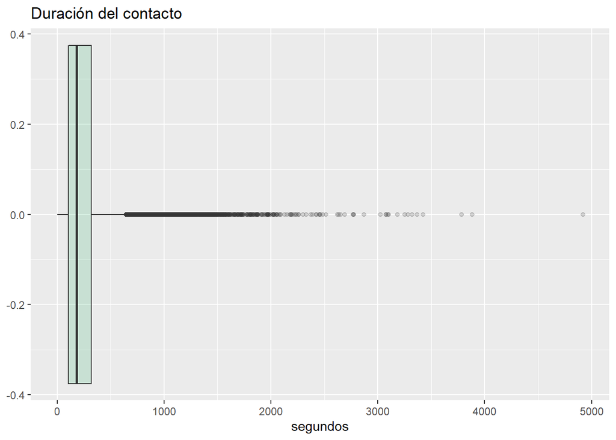

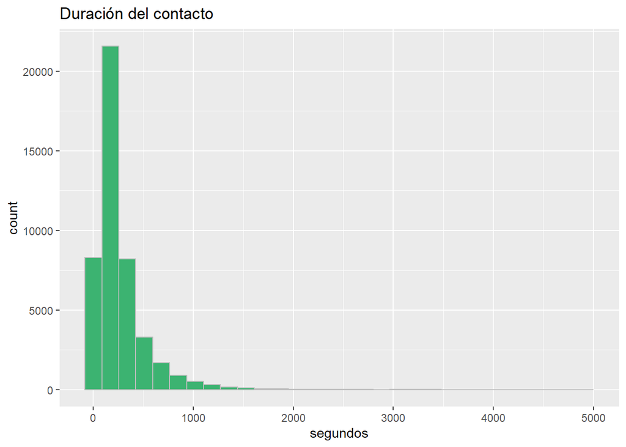

```
Límite superior:  967
```

```
Porcentaje de observaciones por encima del límite superior:  2.55
```

Se les asigna a estas observaciones el valor “NA”:

```
Cantidad de valores NA de la variable duration:  1155
```

#### Variable “campaign”

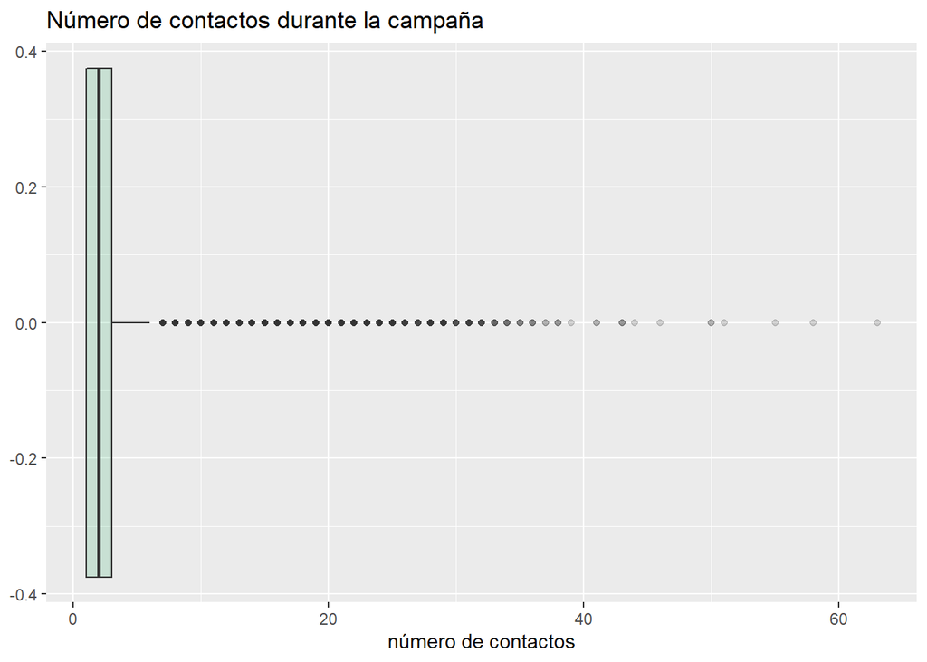

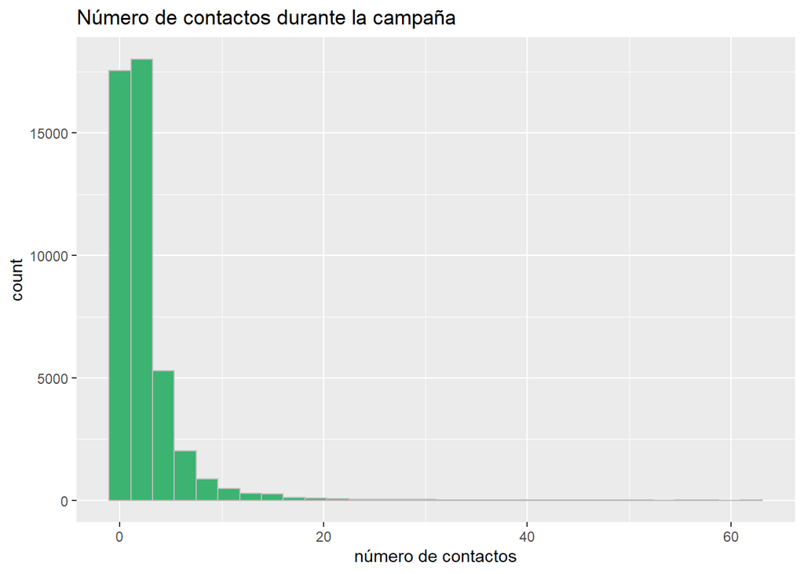

Al igual que en el caso anterior, se calcula sólo el límite superior, considerando tres veces el rango intercuartílico para definir el límite superior:

```
Límite superior:  9
```

```
Porcentaje de observaciones por encima del límite superior:  3.23
```

Estos valores son convertidos en “NA”:

```
Cantidad de valores NA de la variable campaign:  1462
```

#### Variable “previous”

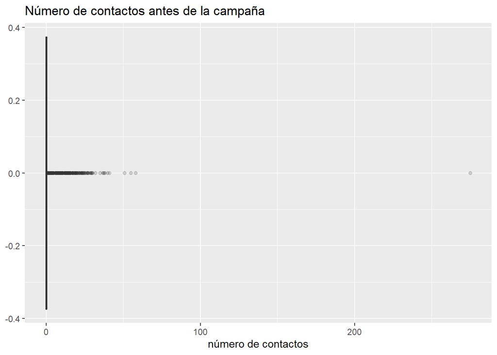

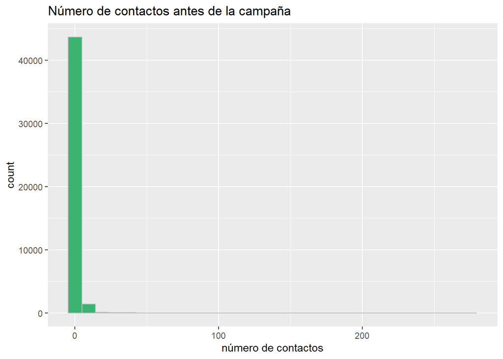

El gráfico indica que esta variable está fuertemente concentrada alrededor del valor 0. Este es el motivo por el cual el límite a partir del cual las observaciones que consideran outliers es 0:

```
Límite superior:  0
```

[output not shown]

Para mayor detalle, la tabla de frecuencias absolutas es útil:

```
    0     1     2     3     4     5     6     7     8     9    10    11    12
36954  2772  2106  1142   714   459   277   205   129    92    67    65    44
   13    14    15    16    17    18    19    20    21    22    23    24    25
   38    19    20    13    15     6    11     8     4     6     8     5     4
   26    27    28    29    30    32    35    37    38    40    41    51    55
    2     5     2     4     3     1     1     2     2     1     1     1     1
   58   275
    1     1
```

El 81.74% de las observaciones tienen un valor 0 para la variable “previous”. Se considerarán valores de hasta 5 contactos previos, el resto se considerarán valores extremos.

```
Cantidad de valores NA de la variable previous:  1064
```

### 3.2.2 Variables categóricas

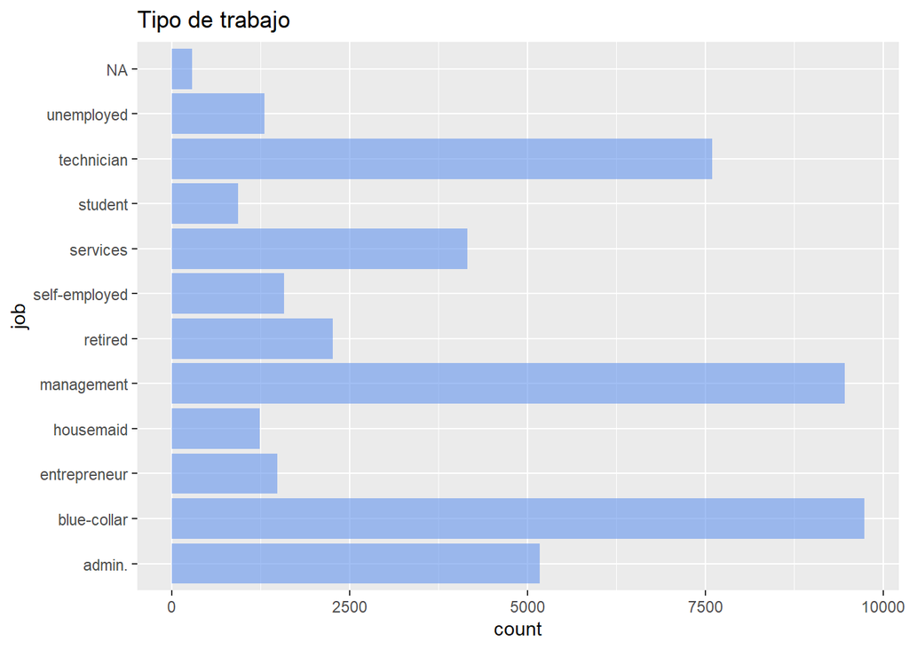

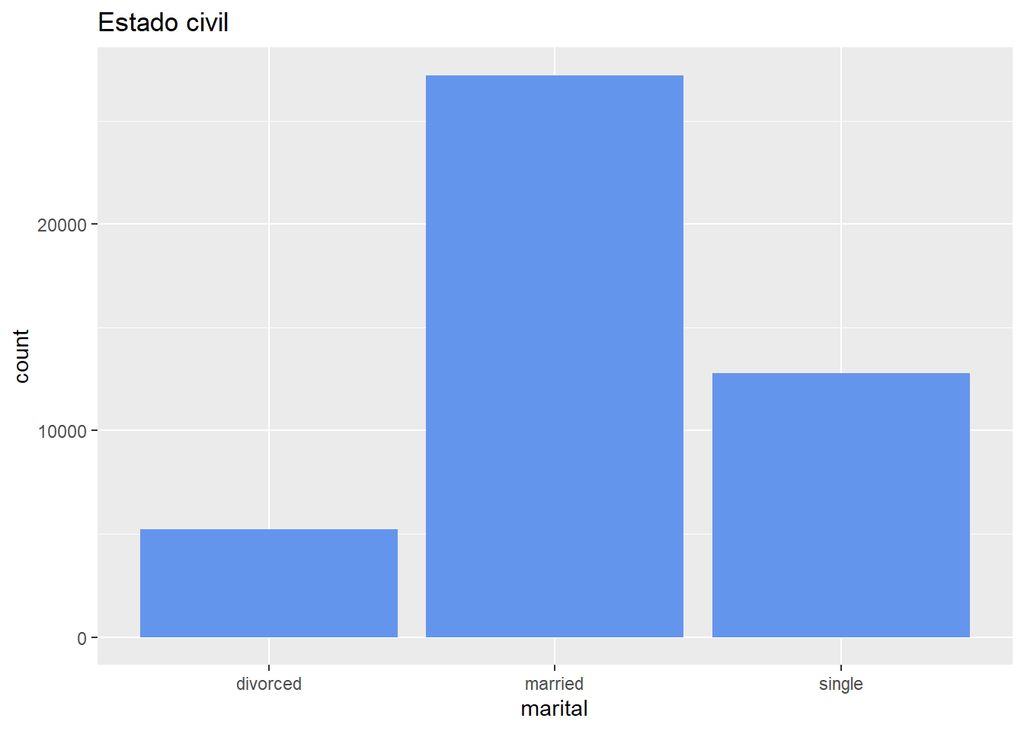

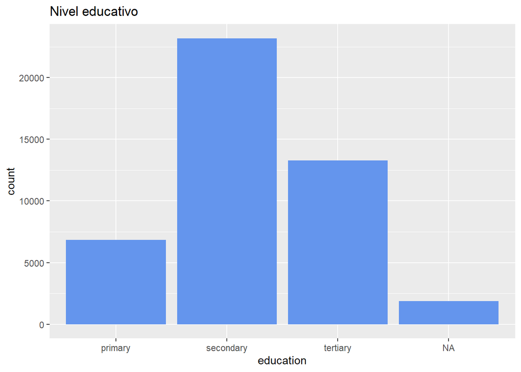

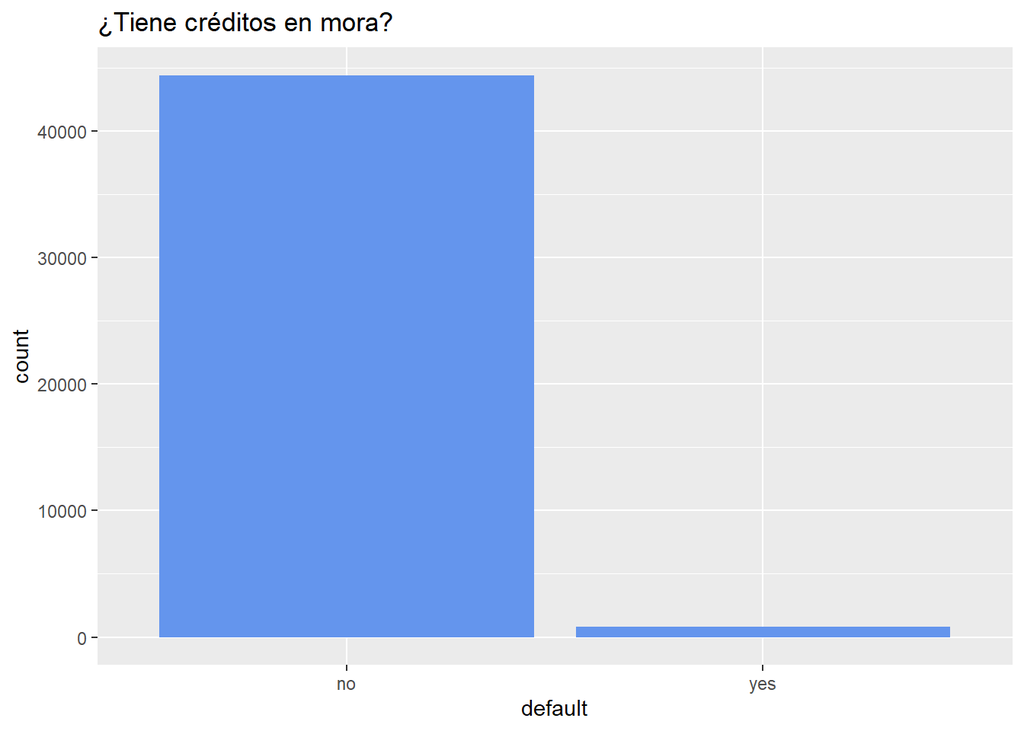

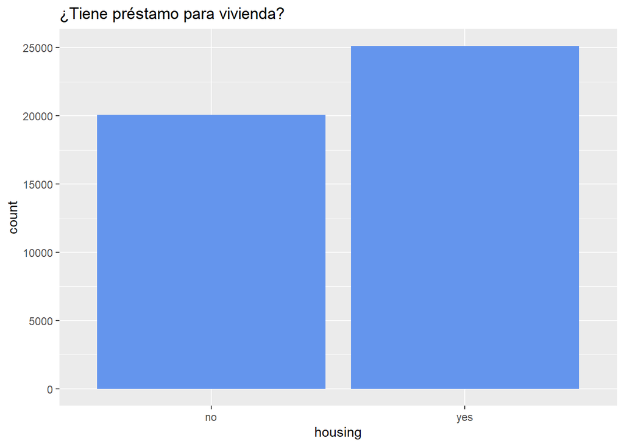

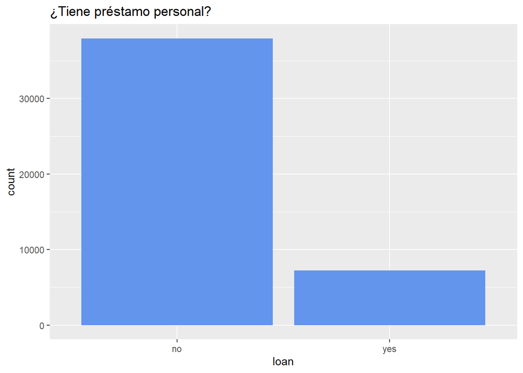

Puede observarse que la variable “default” posee muy pocos caso de “default” = yes. Concretamente:

```
  no  yes
0.98 0.02
```

Sólo un 2% de las observaciones corresponden a casos de default.

### 3.3 Imputación de valores faltantes

Luego de haber convertido los valores extremos en NAs, el dataset tiene la siguiente estructura:

```
      age       job   marital education   default   balance   housing      loan
      433       288         0      1857         0      3727         0         0
 duration  campaign  previous         y
     1155      1462      1064         0
```

Para imputar estos valores faltantes, se utilizará el paquete `mice` (Multivariate Imputation by Chained Equations).

La imputación múltiple por ecuaciones encadenadas es un método robusto e informativo para tratar los datos que faltan en los conjuntos de datos. El procedimiento imputa los datos que faltan en un conjunto de datos mediante una serie iterativa de modelos predictivos. En cada iteración, cada variable especificada en el conjunto de datos se imputa utilizando las demás variables del conjunto de datos.

El proceso se realiza en dos pasos: La función mice(df) produce múltiples copias completas de df, cada una con diferentes imputaciones de los datos que faltan. La función complete() devuelve uno o varios de estos conjuntos de datos.

Pueden utilizarse diferentes métodos de imputación, dependiendo del tipo de variables que se trate.

En este caso en particular, se utilizará el método “random forests”, dado que es aplicable tanto a variables numéricas como a factores. En cuanto a la cantidad de copias completas del dataset a ser generadas, se hará solo una, puesto que se utilizará solo una para entrenar la red neuronal. Múltiples copias del dataframe son utilizadas por ejemplo para hacer regresiones lineales, pero como en este caso solo es necesaria una copia, entonces se genera solo una con `mice`, lo cual es más eficiente computacionalmente.

En primer lugar es necesario convertir a factor todas las variables categóricas:

Luego, se aplica la función mice() sobre el dataframe completo, con el método de imputación “random forests” (rf), una sola copia (m=1) y se fija una semilla para poder reproducir los resultados en caso de ser necesario.La función complete() devuelve el dataframe generado con los datos faltantes imputados:

Puede verse que el dataframe “mice_comp” no tiene valores nulos:

```
[1] FALSE
```

También es interesante comparar los valores promedio de las variables numéricas entre el dataset con NAs y el dataset con NAs imputados:

```
      age                 job           marital          education
 Min.   :18.00   blue-collar:9732   divorced: 5207   primary  : 6851
 1st Qu.:33.00   management :9458   married :27214   secondary:23202
 Median :39.00   technician :7597   single  :12790   tertiary :13301
 Mean   :40.58   admin.     :5171                    NA's     : 1857
 3rd Qu.:48.00   services   :4154
 Max.   :71.00   (Other)    :8811
 NA's   :433     NA's       : 288
 default        balance        housing      loan          duration
 no :44396   Min.   :-8019.0   no :20081   no :37967   Min.   :  0.0
 yes:  815   1st Qu.:   50.0   yes:25130   yes: 7244   1st Qu.:101.0
             Median :  367.0                           Median :175.0
             Mean   :  713.6                           Mean   :230.5
             3rd Qu.: 1064.0                           3rd Qu.:302.0
             Max.   : 4140.0                           Max.   :967.0
             NA's   :3727                              NA's   :1155
    campaign        previous        y
 Min.   :1.000   Min.   :0.0000   no :39922
 1st Qu.:1.000   1st Qu.:0.0000   yes: 5289
 Median :2.000   Median :0.0000
 Mean   :2.336   Mean   :0.3525
 3rd Qu.:3.000   3rd Qu.:0.0000
 Max.   :9.000   Max.   :5.0000
 NA's   :1462    NA's   :1064
```

```
      age            job              marital           education
 Min.   :18.00   Length:45211       Length:45211       Length:45211
 1st Qu.:33.00   Class :character   Class :character   Class :character
 Median :39.00   Mode  :character   Mode  :character   Mode  :character
 Mean   :40.76
 3rd Qu.:48.00
 Max.   :71.00
   default             balance          housing              loan
 Length:45211       Min.   :-8019.0   Length:45211       Length:45211
 Class :character   1st Qu.:   52.0   Class :character   Class :character
 Mode  :character   Median :  372.0   Mode  :character   Mode  :character
                    Mean   :  721.7
                    3rd Qu.: 1076.0
                    Max.   : 4140.0
    duration        campaign        previous           y
 Min.   :  0.0   Min.   :1.000   Min.   :0.0000   Length:45211
 1st Qu.:102.0   1st Qu.:1.000   1st Qu.:0.0000   Class :character
 Median :177.0   Median :2.000   Median :0.0000   Mode  :character
 Mean   :234.2   Mean   :2.353   Mean   :0.3541
 3rd Qu.:308.0   3rd Qu.:3.000   3rd Qu.:0.0000
 Max.   :967.0   Max.   :9.000   Max.   :5.0000
```

Se observa que los valores medios no han variado significativamente. Las variables categóricas también han sido imputadas. Ahora el dataset no contiene valores extremos ni valores faltantes.

por seguridad, se genera una copia del dataset antes de que se le aplique `mice`, y se renombra el dataset generado por `mice` como “data”.

# 4. Preprocesamiento de los datos

A continuación se les da el formato correcto a los datos para poder luego utilizarlos como input para la red neuronal.

Las transformaciones que a realizar son las siguientes:

1. Convertir en dummies todas las variables categóricas
2. Train test split
3. Balanceo de los datos
4. Normalizar los datos

## 4.1 Variables dummies

Es necesario transformar las variables categóricas en variables dummies, es decir, crear tantas columnas binarias como categorías tenga cada variable, eliminando en todos los casos una de las categorías para evitar multicolinealidad.

## 4.2 Train test split

Se lleva a cabo la separación de los datos en set de entremiento y set de testeo, con una distibución 0.7 - 0.3 respectivamente.

## 4.3 Balanceo de datos

Se evaluarán diferentes técnicas de balanceo de los datos, puesto que la clase positiva contiene muy pocas observaciones:

```
   no   yes
0.883 0.117
```

Para ello, se implementan 4 técnicas distintias de undersampling:

#### Tomek Links

```
Instances removed 2491 : 8.91 % of 0 class ; 7.86 % of training ; Time needed 0.03
```

```
        0         1
0.8724526 0.1275474
```

```
       no       yes
0.8830152 0.1169848
```

#### CNN

```
        0         1
0.8824384 0.1175616
```

```
       no       yes
0.8830152 0.1169848
```

#### NCL

```
Number of instances removed from majority class with ENN: 186    Time needed: 2.58
Number of instances removed from majority class after ENN: 4587      Time needed: 0.38
Number of instances removed from majority class: 4773
```

```
        0         1
0.8616385 0.1383615
```

```
        0         1
0.8824792 0.1175208
```

#### OSS

```
Instances removed 2491 : 8.91 % of 0 class ; 7.86 % of training ; Time needed 0.03
```

```
        0         1
0.8724483 0.1275517
```

```
        0         1
0.8824792 0.1175208
```

## 4.4 Datos normalizados

Para lograr una mejor performance de las redes neuronales, se normalizan las features.

# 5. Aplicación de modelos

## 5.1 Redes neuronales

### 5.1.1 Red neuronal con una capa

Se analiza una combinación de 60 modelos distintos, combinando diferente cantidad de neuronas, 2 funciones de activación y diversos valores de threshold.

```
   hidden1 actfction thresh  accuracy sensitivity
15      10  logistic    0.6 0.8824225   0.4472843
```

Puede verse que con una estructura de una capa, el mejor resultado se obtiene con 10 neuronas, función de activación logística y un threshold de 0.6. El accuracy es de 0.8824225 y la sensitivity de 0.4472843. Este resultado no es demasiado bueno.

### 5.1.2 Red neuronal con dos capas

Se ha intentado realizar la búsqueda del mejor modelo con dos capas a través de la función definida anteriormente, pero no se ha logrado que la misma finalice su ejecución satisfactoriamente. Tanto en este caso de dos capas, como para tres y cuatro capas, ha ocurrido lo mismo.

El problema resulta ser que algunas configuraciones de parámetros no permiten que el modelo converja, y por lo tanto la ejecución de la función se corta cuando esto sucede. A pesar de que se ha introducido la función `tryCatch` que permite saltear estos modelos que no converjen para que el loop siga ejecutándose, no se ha logrado que la función finalice su ejecución.

Por este motivo se procederá a analizar modelos de dos y tres capas de forma manual.

#### Función de propagación: `rprop+`

##### 15 y 10 capas, función de activación logística

```
Confusion Matrix and Statistics

          Reference
Prediction     0     1
         0 11259   949
         1   699   616

               Accuracy : 0.8781
                 95% CI : (0.8725, 0.8836)
    No Information Rate : 0.8843
    P-Value [Acc > NIR] : 0.9872

                  Kappa : 0.3602

 Mcnemar's Test P-Value : 8.587e-10

            Sensitivity : 0.39361
            Specificity : 0.94155
         Pos Pred Value : 0.46844
         Neg Pred Value : 0.92226
             Prevalence : 0.11573
         Detection Rate : 0.04555
   Detection Prevalence : 0.09724
      Balanced Accuracy : 0.66758

       'Positive' Class : 1
```

##### 15 y 10 capas, función de activación tangencial:

```
Confusion Matrix and Statistics

          Reference
Prediction     0     1
         0 11139   857
         1   819   708

               Accuracy : 0.8761
                 95% CI : (0.8704, 0.8816)
    No Information Rate : 0.8843
    P-Value [Acc > NIR] : 0.9985

                  Kappa : 0.388

 Mcnemar's Test P-Value : 0.3661

            Sensitivity : 0.45240
            Specificity : 0.93151
         Pos Pred Value : 0.46365
         Neg Pred Value : 0.92856
             Prevalence : 0.11573
         Detection Rate : 0.05236
   Detection Prevalence : 0.11292
      Balanced Accuracy : 0.69195

       'Positive' Class : 1
```

##### 9 y 4 capas, función de activación logística:

```
Confusion Matrix and Statistics

          Reference
Prediction     0     1
         0 11226   935
         1   732   630

               Accuracy : 0.8767
                 95% CI : (0.8711, 0.8822)
    No Information Rate : 0.8843
    P-Value [Acc > NIR] : 0.9969

                  Kappa : 0.3617

 Mcnemar's Test P-Value : 7.518e-07

            Sensitivity : 0.40256
            Specificity : 0.93879
         Pos Pred Value : 0.46256
         Neg Pred Value : 0.92311
             Prevalence : 0.11573
         Detection Rate : 0.04659
   Detection Prevalence : 0.10072
      Balanced Accuracy : 0.67067

       'Positive' Class : 1
```

##### 9 y 4 capas, función de activación tangencial

```
Confusion Matrix and Statistics

          Reference
Prediction     0     1
         0 11198   877
         1   760   688

               Accuracy : 0.8789
                 95% CI : (0.8733, 0.8844)
    No Information Rate : 0.8843
    P-Value [Acc > NIR] : 0.973779

                  Kappa : 0.3887

 Mcnemar's Test P-Value : 0.004143

            Sensitivity : 0.43962
            Specificity : 0.93644
         Pos Pred Value : 0.47514
         Neg Pred Value : 0.92737
             Prevalence : 0.11573
         Detection Rate : 0.05088
   Detection Prevalence : 0.10708
      Balanced Accuracy : 0.68803

       'Positive' Class : 1
```

##### 30 y 20 capas, función de activación logística:

```
Confusion Matrix and Statistics

          Reference
Prediction     0     1
         0 11334   988
         1   624   577

               Accuracy : 0.8808
                 95% CI : (0.8752, 0.8862)
    No Information Rate : 0.8843
    P-Value [Acc > NIR] : 0.8988

                  Kappa : 0.3521

 Mcnemar's Test P-Value : <2e-16

            Sensitivity : 0.36869
            Specificity : 0.94782
         Pos Pred Value : 0.48043
         Neg Pred Value : 0.91982
             Prevalence : 0.11573
         Detection Rate : 0.04267
   Detection Prevalence : 0.08881
      Balanced Accuracy : 0.65825

       'Positive' Class : 1
```

##### 30 y 20 capas, función de activación tangencial:

```
Confusion Matrix and Statistics

          Reference
Prediction     0     1
         0 11303   978
         1   655   587

               Accuracy : 0.8792
                 95% CI : (0.8736, 0.8847)
    No Information Rate : 0.8843
    P-Value [Acc > NIR] : 0.9666

                  Kappa : 0.3519

 Mcnemar's Test P-Value : 1.609e-15

            Sensitivity : 0.37508
            Specificity : 0.94522
         Pos Pred Value : 0.47262
         Neg Pred Value : 0.92036
             Prevalence : 0.11573
         Detection Rate : 0.04341
   Detection Prevalence : 0.09184
      Balanced Accuracy : 0.66015

       'Positive' Class : 1
```

##### 23 y 2 capas, función de activación logística:

```
Confusion Matrix and Statistics

          Reference
Prediction     0     1
         0 11206   876
         1   752   689

               Accuracy : 0.8796
                 95% CI : (0.874, 0.8851)
    No Information Rate : 0.8843
    P-Value [Acc > NIR] : 0.9555

                  Kappa : 0.3908

 Mcnemar's Test P-Value : 0.0023

            Sensitivity : 0.44026
            Specificity : 0.93711
         Pos Pred Value : 0.47814
         Neg Pred Value : 0.92750
             Prevalence : 0.11573
         Detection Rate : 0.05095
   Detection Prevalence : 0.10656
      Balanced Accuracy : 0.68868

       'Positive' Class : 1
```

##### 23 y 2 capas, función de activación tangencial

```
Confusion Matrix and Statistics

          Reference
Prediction     0     1
         0 11131   856
         1   827   709

               Accuracy : 0.8755
                 95% CI : (0.8699, 0.8811)
    No Information Rate : 0.8843
    P-Value [Acc > NIR] : 0.9992

                  Kappa : 0.387

 Mcnemar's Test P-Value : 0.4949

            Sensitivity : 0.45304
            Specificity : 0.93084
         Pos Pred Value : 0.46159
         Neg Pred Value : 0.92859
             Prevalence : 0.11573
         Detection Rate : 0.05243
   Detection Prevalence : 0.11358
      Balanced Accuracy : 0.69194

       'Positive' Class : 1
```

#### Función de propagación: `backprop`

##### 15 y 10 capas, función de activación logística:

```
Confusion Matrix and Statistics

          Reference
Prediction     0     1
         0 11958  1565
         1     0     0

               Accuracy : 0.8843
                 95% CI : (0.8788, 0.8896)
    No Information Rate : 0.8843
    P-Value [Acc > NIR] : 0.5067

                  Kappa : 0

 Mcnemar's Test P-Value : <2e-16

            Sensitivity : 0.0000
            Specificity : 1.0000
         Pos Pred Value :    NaN
         Neg Pred Value : 0.8843
             Prevalence : 0.1157
         Detection Rate : 0.0000
   Detection Prevalence : 0.0000
      Balanced Accuracy : 0.5000

       'Positive' Class : 1
```

##### 15 y 10 capas, función de activación tangencial

```
Confusion Matrix and Statistics

          Reference
Prediction     0     1
         0 11932  1562
         1    26     3

               Accuracy : 0.8826
                 95% CI : (0.877, 0.888)
    No Information Rate : 0.8843
    P-Value [Acc > NIR] : 0.7369

                  Kappa : -4e-04

 Mcnemar's Test P-Value : <2e-16

            Sensitivity : 0.0019169
            Specificity : 0.9978257
         Pos Pred Value : 0.1034483
         Neg Pred Value : 0.8842448
             Prevalence : 0.1157288
         Detection Rate : 0.0002218
   Detection Prevalence : 0.0021445
      Balanced Accuracy : 0.4998713

       'Positive' Class : 1
```

##### 9 y 4 capas, función de activación logística:

```
Confusion Matrix and Statistics

          Reference
Prediction     0     1
         0 11958  1565
         1     0     0

               Accuracy : 0.8843
                 95% CI : (0.8788, 0.8896)
    No Information Rate : 0.8843
    P-Value [Acc > NIR] : 0.5067

                  Kappa : 0

 Mcnemar's Test P-Value : <2e-16

            Sensitivity : 0.0000
            Specificity : 1.0000
         Pos Pred Value :    NaN
         Neg Pred Value : 0.8843
             Prevalence : 0.1157
         Detection Rate : 0.0000
   Detection Prevalence : 0.0000
      Balanced Accuracy : 0.5000

       'Positive' Class : 1
```

##### 9 y 4 capas, función de activación tangencial:

```
Confusion Matrix and Statistics

          Reference
Prediction     0     1
         0 11958  1565
         1     0     0

               Accuracy : 0.8843
                 95% CI : (0.8788, 0.8896)
    No Information Rate : 0.8843
    P-Value [Acc > NIR] : 0.5067

                  Kappa : 0

 Mcnemar's Test P-Value : <2e-16

            Sensitivity : 0.0000
            Specificity : 1.0000
         Pos Pred Value :    NaN
         Neg Pred Value : 0.8843
             Prevalence : 0.1157
         Detection Rate : 0.0000
   Detection Prevalence : 0.0000
      Balanced Accuracy : 0.5000

       'Positive' Class : 1
```

##### 30 y 20 capas, función de activación logística:

```
Confusion Matrix and Statistics

          Reference
Prediction     0     1
         0 11958  1565
         1     0     0

               Accuracy : 0.8843
                 95% CI : (0.8788, 0.8896)
    No Information Rate : 0.8843
    P-Value [Acc > NIR] : 0.5067

                  Kappa : 0

 Mcnemar's Test P-Value : <2e-16

            Sensitivity : 0.0000
            Specificity : 1.0000
         Pos Pred Value :    NaN
         Neg Pred Value : 0.8843
             Prevalence : 0.1157
         Detection Rate : 0.0000
   Detection Prevalence : 0.0000
      Balanced Accuracy : 0.5000

       'Positive' Class : 1
```

##### 30 y 20 capas, función de activación tangencial:

```
Confusion Matrix and Statistics

          Reference
Prediction     0     1
         0 11958  1565
         1     0     0

               Accuracy : 0.8843
                 95% CI : (0.8788, 0.8896)
    No Information Rate : 0.8843
    P-Value [Acc > NIR] : 0.5067

                  Kappa : 0

 Mcnemar's Test P-Value : <2e-16

            Sensitivity : 0.0000
            Specificity : 1.0000
         Pos Pred Value :    NaN
         Neg Pred Value : 0.8843
             Prevalence : 0.1157
         Detection Rate : 0.0000
   Detection Prevalence : 0.0000
      Balanced Accuracy : 0.5000

       'Positive' Class : 1
```

##### 23 y 2 capas, función de activación logística:

```
Confusion Matrix and Statistics

          Reference
Prediction     0     1
         0     0     0
         1 11958  1565

               Accuracy : 0.1157
                 95% CI : (0.1104, 0.1212)
    No Information Rate : 0.8843
    P-Value [Acc > NIR] : 1

                  Kappa : 0

 Mcnemar's Test P-Value : <2e-16

            Sensitivity : 1.0000
            Specificity : 0.0000
         Pos Pred Value : 0.1157
         Neg Pred Value :    NaN
             Prevalence : 0.1157
         Detection Rate : 0.1157
   Detection Prevalence : 1.0000
      Balanced Accuracy : 0.5000

       'Positive' Class : 1
```

##### 23 y 2 capas, función de activación tangencial

```
Confusion Matrix and Statistics

          Reference
Prediction     0     1
         0 11958  1565
         1     0     0

               Accuracy : 0.8843
                 95% CI : (0.8788, 0.8896)
    No Information Rate : 0.8843
    P-Value [Acc > NIR] : 0.5067

                  Kappa : 0

 Mcnemar's Test P-Value : <2e-16

            Sensitivity : 0.0000
            Specificity : 1.0000
         Pos Pred Value :    NaN
         Neg Pred Value : 0.8843
             Prevalence : 0.1157
         Detection Rate : 0.0000
   Detection Prevalence : 0.0000
      Balanced Accuracy : 0.5000

       'Positive' Class : 1
```

### 5.1.3 Red neuronal con tres capas

#### Función de propagación: `rprop+`

##### 15, 10 y 5 capas, función de activación logística:

```
Confusion Matrix and Statistics

          Reference
Prediction     0     1
         0 11183   920
         1   775   645

               Accuracy : 0.8747
                 95% CI : (0.869, 0.8802)
    No Information Rate : 0.8843
    P-Value [Acc > NIR] : 0.9997403

                  Kappa : 0.3619

 Mcnemar's Test P-Value : 0.0004694

            Sensitivity : 0.4121
            Specificity : 0.9352
         Pos Pred Value : 0.4542
         Neg Pred Value : 0.9240
             Prevalence : 0.1157
         Detection Rate : 0.0477
   Detection Prevalence : 0.1050
      Balanced Accuracy : 0.6737

       'Positive' Class : 1
```

```
[1] 15
```

##### 15, 10 y 5 capas, función de activación tangencial:

```
Confusion Matrix and Statistics

          Reference
Prediction     0     1
         0 11144   867
         1   814   698

               Accuracy : 0.8757
                 95% CI : (0.87, 0.8812)
    No Information Rate : 0.8843
    P-Value [Acc > NIR] : 0.9990

                  Kappa : 0.3836

 Mcnemar's Test P-Value : 0.2047

            Sensitivity : 0.44601
            Specificity : 0.93193
         Pos Pred Value : 0.46164
         Neg Pred Value : 0.92782
             Prevalence : 0.11573
         Detection Rate : 0.05162
   Detection Prevalence : 0.11181
      Balanced Accuracy : 0.68897

       'Positive' Class : 1
```

##### 20, 15 y 10 capas, función de activación logística:

```
Confusion Matrix and Statistics

          Reference
Prediction     0     1
         0 11227   945
         1   731   620

               Accuracy : 0.8761
                 95% CI : (0.8704, 0.8816)
    No Information Rate : 0.8843
    P-Value [Acc > NIR] : 0.9985

                  Kappa : 0.3562

 Mcnemar's Test P-Value : 1.962e-07

            Sensitivity : 0.39617
            Specificity : 0.93887
         Pos Pred Value : 0.45892
         Neg Pred Value : 0.92236
             Prevalence : 0.11573
         Detection Rate : 0.04585
   Detection Prevalence : 0.09990
      Balanced Accuracy : 0.66752

       'Positive' Class : 1
```

##### 20, 15 y 10 capas, función de activación tangencial:

```
Confusion Matrix and Statistics

          Reference
Prediction     0     1
         0 11139   863
         1   819   702

               Accuracy : 0.8756
                 95% CI : (0.8699, 0.8811)
    No Information Rate : 0.8843
    P-Value [Acc > NIR] : 0.9991

                  Kappa : 0.3848

 Mcnemar's Test P-Value : 0.2944

            Sensitivity : 0.44856
            Specificity : 0.93151
         Pos Pred Value : 0.46154
         Neg Pred Value : 0.92810
             Prevalence : 0.11573
         Detection Rate : 0.05191
   Detection Prevalence : 0.11248
      Balanced Accuracy : 0.69004

       'Positive' Class : 1
```

##### 10, 8 y 4 capas, función de activación logística:

```
Confusion Matrix and Statistics

          Reference
Prediction     0     1
         0 11201   935
         1   757   630

               Accuracy : 0.8749
                 95% CI : (0.8692, 0.8804)
    No Information Rate : 0.8843
    P-Value [Acc > NIR] : 0.9997

                  Kappa : 0.3569

 Mcnemar's Test P-Value : 1.685e-05

            Sensitivity : 0.40256
            Specificity : 0.93670
         Pos Pred Value : 0.45422
         Neg Pred Value : 0.92296
             Prevalence : 0.11573
         Detection Rate : 0.04659
   Detection Prevalence : 0.10257
      Balanced Accuracy : 0.66963

       'Positive' Class : 1
```

##### 10, 8 y 4 capas capas, función de activación tangencial

```
Confusion Matrix and Statistics

          Reference
Prediction     0     1
         0 11237   953
         1   721   612

               Accuracy : 0.8762
                 95% CI : (0.8705, 0.8817)
    No Information Rate : 0.8843
    P-Value [Acc > NIR] : 0.9982

                  Kappa : 0.3535

 Mcnemar's Test P-Value : 1.643e-08

            Sensitivity : 0.39105
            Specificity : 0.93971
         Pos Pred Value : 0.45911
         Neg Pred Value : 0.92182
             Prevalence : 0.11573
         Detection Rate : 0.04526
   Detection Prevalence : 0.09857
      Balanced Accuracy : 0.66538

       'Positive' Class : 1
```

##### 8, 6 y 4 capas, función de activación logística

```
Confusion Matrix and Statistics

          Reference
Prediction     0     1
         0 11159   904
         1   799   661

               Accuracy : 0.8741
                 95% CI : (0.8684, 0.8796)
    No Information Rate : 0.8843
    P-Value [Acc > NIR] : 0.99988

                  Kappa : 0.3662

 Mcnemar's Test P-Value : 0.01173

            Sensitivity : 0.42236
            Specificity : 0.93318
         Pos Pred Value : 0.45274
         Neg Pred Value : 0.92506
             Prevalence : 0.11573
         Detection Rate : 0.04888
   Detection Prevalence : 0.10796
      Balanced Accuracy : 0.67777

       'Positive' Class : 1
```

##### 8, 6 y 4 capas, función de activación tangencial:

```
Confusion Matrix and Statistics

          Reference
Prediction     0     1
         0 11196   881
         1   762   684

               Accuracy : 0.8785
                 95% CI : (0.8729, 0.884)
    No Information Rate : 0.8843
    P-Value [Acc > NIR] : 0.982073

                  Kappa : 0.3861

 Mcnemar's Test P-Value : 0.003601

            Sensitivity : 0.43706
            Specificity : 0.93628
         Pos Pred Value : 0.47303
         Neg Pred Value : 0.92705
             Prevalence : 0.11573
         Detection Rate : 0.05058
   Detection Prevalence : 0.10693
      Balanced Accuracy : 0.68667

       'Positive' Class : 1
```

##### 7, 5 y 3 capas, función de activación logística:

```
Confusion Matrix and Statistics

          Reference
Prediction     0     1
         0 11232   874
         1   726   691

               Accuracy : 0.8817
                 95% CI : (0.8761, 0.8871)
    No Information Rate : 0.8843
    P-Value [Acc > NIR] : 0.8301118

                  Kappa : 0.3971

 Mcnemar's Test P-Value : 0.0002378

            Sensitivity : 0.4415
            Specificity : 0.9393
         Pos Pred Value : 0.4876
         Neg Pred Value : 0.9278
             Prevalence : 0.1157
         Detection Rate : 0.0511
   Detection Prevalence : 0.1048
      Balanced Accuracy : 0.6904

       'Positive' Class : 1
```

##### 7, 5 y 3 capas capas, función de activación tangencial:

```
Confusion Matrix and Statistics

          Reference
Prediction     0     1
         0 11182   904
         1   776   661

               Accuracy : 0.8758
                 95% CI : (0.8701, 0.8813)
    No Information Rate : 0.8843
    P-Value [Acc > NIR] : 0.998951

                  Kappa : 0.3706

 Mcnemar's Test P-Value : 0.001945

            Sensitivity : 0.42236
            Specificity : 0.93511
         Pos Pred Value : 0.45999
         Neg Pred Value : 0.92520
             Prevalence : 0.11573
         Detection Rate : 0.04888
   Detection Prevalence : 0.10626
      Balanced Accuracy : 0.67874

       'Positive' Class : 1
```

##### 6, 4 y 2 capas, función de activación logística:

```
Confusion Matrix and Statistics

          Reference
Prediction     0     1
         0 11204   881
         1   754   684

               Accuracy : 0.8791
                 95% CI : (0.8735, 0.8845)
    No Information Rate : 0.8843
    P-Value [Acc > NIR] : 0.970380

                  Kappa : 0.3877

 Mcnemar's Test P-Value : 0.001833

            Sensitivity : 0.43706
            Specificity : 0.93695
         Pos Pred Value : 0.47566
         Neg Pred Value : 0.92710
             Prevalence : 0.11573
         Detection Rate : 0.05058
   Detection Prevalence : 0.10634
      Balanced Accuracy : 0.68700

       'Positive' Class : 1
```

##### 6, 4 y 2 capas capas capas, función de activación tangencial:

```
Confusion Matrix and Statistics

          Reference
Prediction     0     1
         0 11272   938
         1   686   627

               Accuracy : 0.8799
                 95% CI : (0.8743, 0.8853)
    No Information Rate : 0.8843
    P-Value [Acc > NIR] : 0.9446

                  Kappa : 0.3691

 Mcnemar's Test P-Value : 4.71e-10

            Sensitivity : 0.40064
            Specificity : 0.94263
         Pos Pred Value : 0.47753
         Neg Pred Value : 0.92318
             Prevalence : 0.11573
         Detection Rate : 0.04637
   Detection Prevalence : 0.09709
      Balanced Accuracy : 0.67164

       'Positive' Class : 1
```

#### Función de propagación: `backprop`

##### 15, 10 y 5 capas, función de activación logística:

```
Confusion Matrix and Statistics

          Reference
Prediction     0     1
         0 11958  1565
         1     0     0

               Accuracy : 0.8843
                 95% CI : (0.8788, 0.8896)
    No Information Rate : 0.8843
    P-Value [Acc > NIR] : 0.5067

                  Kappa : 0

 Mcnemar's Test P-Value : <2e-16

            Sensitivity : 0.0000
            Specificity : 1.0000
         Pos Pred Value :    NaN
         Neg Pred Value : 0.8843
             Prevalence : 0.1157
         Detection Rate : 0.0000
   Detection Prevalence : 0.0000
      Balanced Accuracy : 0.5000

       'Positive' Class : 1
```

##### 15, 10 y 5 capas, función de activación tangencial:

```
Confusion Matrix and Statistics

          Reference
Prediction     0     1
         0 11680  1520
         1   278    45

               Accuracy : 0.867
                 95% CI : (0.8612, 0.8727)
    No Information Rate : 0.8843
    P-Value [Acc > NIR] : 1

                  Kappa : 0.0084

 Mcnemar's Test P-Value : <2e-16

            Sensitivity : 0.028754
            Specificity : 0.976752
         Pos Pred Value : 0.139319
         Neg Pred Value : 0.884848
             Prevalence : 0.115729
         Detection Rate : 0.003328
   Detection Prevalence : 0.023885
      Balanced Accuracy : 0.502753

       'Positive' Class : 1
```

##### 20, 15 y 10 capas, función de activación logística:

```
Confusion Matrix and Statistics

          Reference
Prediction     0     1
         0 11958  1565
         1     0     0

               Accuracy : 0.8843
                 95% CI : (0.8788, 0.8896)
    No Information Rate : 0.8843
    P-Value [Acc > NIR] : 0.5067

                  Kappa : 0

 Mcnemar's Test P-Value : <2e-16

            Sensitivity : 0.0000
            Specificity : 1.0000
         Pos Pred Value :    NaN
         Neg Pred Value : 0.8843
             Prevalence : 0.1157
         Detection Rate : 0.0000
   Detection Prevalence : 0.0000
      Balanced Accuracy : 0.5000

       'Positive' Class : 1
```

##### 20, 15 y 10 capas, función de activación tangencial:

```
Confusion Matrix and Statistics

          Reference
Prediction     0     1
         0 11958  1565
         1     0     0

               Accuracy : 0.8843
                 95% CI : (0.8788, 0.8896)
    No Information Rate : 0.8843
    P-Value [Acc > NIR] : 0.5067

                  Kappa : 0

 Mcnemar's Test P-Value : <2e-16

            Sensitivity : 0.0000
            Specificity : 1.0000
         Pos Pred Value :    NaN
         Neg Pred Value : 0.8843
             Prevalence : 0.1157
         Detection Rate : 0.0000
   Detection Prevalence : 0.0000
      Balanced Accuracy : 0.5000

       'Positive' Class : 1
```

##### 10, 8 y 4 capas, función de activación logística:

```
Confusion Matrix and Statistics

          Reference
Prediction     0     1
         0 11958  1565
         1     0     0

               Accuracy : 0.8843
                 95% CI : (0.8788, 0.8896)
    No Information Rate : 0.8843
    P-Value [Acc > NIR] : 0.5067

                  Kappa : 0

 Mcnemar's Test P-Value : <2e-16

            Sensitivity : 0.0000
            Specificity : 1.0000
         Pos Pred Value :    NaN
         Neg Pred Value : 0.8843
             Prevalence : 0.1157
         Detection Rate : 0.0000
   Detection Prevalence : 0.0000
      Balanced Accuracy : 0.5000

       'Positive' Class : 1
```

##### 10, 8 y 4 capas capas, función de activación tangencial:

```
Confusion Matrix and Statistics

          Reference
Prediction     0     1
         0 11958  1565
         1     0     0

               Accuracy : 0.8843
                 95% CI : (0.8788, 0.8896)
    No Information Rate : 0.8843
    P-Value [Acc > NIR] : 0.5067

                  Kappa : 0

 Mcnemar's Test P-Value : <2e-16

            Sensitivity : 0.0000
            Specificity : 1.0000
         Pos Pred Value :    NaN
         Neg Pred Value : 0.8843
             Prevalence : 0.1157
         Detection Rate : 0.0000
   Detection Prevalence : 0.0000
      Balanced Accuracy : 0.5000

       'Positive' Class : 1
```

8, 6 y 4 capas, función de activación logística:

```
Confusion Matrix and Statistics

          Reference
Prediction     0     1
         0 11958  1565
         1     0     0

               Accuracy : 0.8843
                 95% CI : (0.8788, 0.8896)
    No Information Rate : 0.8843
    P-Value [Acc > NIR] : 0.5067

                  Kappa : 0

 Mcnemar's Test P-Value : <2e-16

            Sensitivity : 0.0000
            Specificity : 1.0000
         Pos Pred Value :    NaN
         Neg Pred Value : 0.8843
             Prevalence : 0.1157
         Detection Rate : 0.0000
   Detection Prevalence : 0.0000
      Balanced Accuracy : 0.5000

       'Positive' Class : 1
```

##### 8, 6 y 4 capas, función de activación tangencial:

```
Confusion Matrix and Statistics

          Reference
Prediction     0     1
         0 11958  1565
         1     0     0

               Accuracy : 0.8843
                 95% CI : (0.8788, 0.8896)
    No Information Rate : 0.8843
    P-Value [Acc > NIR] : 0.5067

                  Kappa : 0

 Mcnemar's Test P-Value : <2e-16

            Sensitivity : 0.0000
            Specificity : 1.0000
         Pos Pred Value :    NaN
         Neg Pred Value : 0.8843
             Prevalence : 0.1157
         Detection Rate : 0.0000
   Detection Prevalence : 0.0000
      Balanced Accuracy : 0.5000

       'Positive' Class : 1
```

##### 7, 5 y 3 capas, función de activación logística:

```
Confusion Matrix and Statistics

          Reference
Prediction     0     1
         0 11958  1565
         1     0     0

               Accuracy : 0.8843
                 95% CI : (0.8788, 0.8896)
    No Information Rate : 0.8843
    P-Value [Acc > NIR] : 0.5067

                  Kappa : 0

 Mcnemar's Test P-Value : <2e-16

            Sensitivity : 0.0000
            Specificity : 1.0000
         Pos Pred Value :    NaN
         Neg Pred Value : 0.8843
             Prevalence : 0.1157
         Detection Rate : 0.0000
   Detection Prevalence : 0.0000
      Balanced Accuracy : 0.5000

       'Positive' Class : 1
```

##### 7, 5 y 3 capas capas, función de activación tangencial:

```
Confusion Matrix and Statistics

          Reference
Prediction     0     1
         0 11958  1565
         1     0     0

               Accuracy : 0.8843
                 95% CI : (0.8788, 0.8896)
    No Information Rate : 0.8843
    P-Value [Acc > NIR] : 0.5067

                  Kappa : 0

 Mcnemar's Test P-Value : <2e-16

            Sensitivity : 0.0000
            Specificity : 1.0000
         Pos Pred Value :    NaN
         Neg Pred Value : 0.8843
             Prevalence : 0.1157
         Detection Rate : 0.0000
   Detection Prevalence : 0.0000
      Balanced Accuracy : 0.5000

       'Positive' Class : 1
```

##### 6, 4 y 2 capas, función de activación logística:

```
Confusion Matrix and Statistics

          Reference
Prediction     0     1
         0 11958  1565
         1     0     0

               Accuracy : 0.8843
                 95% CI : (0.8788, 0.8896)
    No Information Rate : 0.8843
    P-Value [Acc > NIR] : 0.5067

                  Kappa : 0

 Mcnemar's Test P-Value : <2e-16

            Sensitivity : 0.0000
            Specificity : 1.0000
         Pos Pred Value :    NaN
         Neg Pred Value : 0.8843
             Prevalence : 0.1157
         Detection Rate : 0.0000
   Detection Prevalence : 0.0000
      Balanced Accuracy : 0.5000

       'Positive' Class : 1
```

##### 6, 4 y 2 capas capas capas, función de activación tangencial:

```
Confusion Matrix and Statistics

          Reference
Prediction     0     1
         0 11958  1565
         1     0     0

               Accuracy : 0.8843
                 95% CI : (0.8788, 0.8896)
    No Information Rate : 0.8843
    P-Value [Acc > NIR] : 0.5067

                  Kappa : 0

 Mcnemar's Test P-Value : <2e-16

            Sensitivity : 0.0000
            Specificity : 1.0000
         Pos Pred Value :    NaN
         Neg Pred Value : 0.8843
             Prevalence : 0.1157
         Detection Rate : 0.0000
   Detection Prevalence : 0.0000
      Balanced Accuracy : 0.5000

       'Positive' Class : 1
```

# 6. Análisis de los resultados

A continuación se procede a analizar los resultados obtenidos y seleccionar la mejor opción de cada estructura de res, para finalmente comparar los 3 pre-seleccionados y escoger la mejor red.

Se escogerá el mejor modelo en función de la sensitivity, puesto que estamos frente a un problema de clasificación desbalanceada, y por lo tanto interesa que se clasifique bien la clase minoritaria, en este caso en particular, la clase positiva, de suscripción del depósito.

## Redes de 1 capa

```
   hidden1 actfction thresh  accuracy sensitivity
15      10  logistic    0.6 0.8824225   0.4472843
```

Puede verse que con una estructura de una capa, el mejor resultado se obtiene con 10 neuronas, función de activación logística y un threshold de 0.6. El accuracy es de 0.8824225 y la sensitivity de 0.4472843. Este resultado no es demasiado bueno.

## Redes de 2 capas

```
   neuronas_1capa neuronas_2capa act_fction alg_propagacion threshold  accuracy
1              15             10  logistica          rprop+         5 0.8781336
2              15             10 tangencial          rprop+         5 0.8760630
3               9              4  logistica          rprop+         4 0.8767285
4               9              4 tangencial          rprop+         4 0.8789470
5              30             20  logística          rprop+         6 0.8807957
6              30             20 tangencial          rprop+        10 0.8792428
7              23              2  logística          rprop+         6 0.8796125
8              23              2 tangencial          rprop+        10 0.8755454
9              15             10  logistica        backprop         5 0.8842712
10             15             10 tangencial        backprop         5 0.8825704
11              9              4  logistica        backprop         4 0.8842712
12              9              4 tangencial        backprop         4 0.8842712
13             30             20  logistica        backprop         6 0.8842712
14             30             20 tangencial        backprop        10 0.8842712
```

[output cut: 19 more lines]

Puede verse que la sensitivity en el caso de redes neuronales con dos capas varía desde 0 hasta 1. El los casos en que es igual a 0, el algoritmo clasifica todas las observaciones como 0, mientras que cuando es de 1, todo es predicho como caso positivo. Esto ocurre con `backprop`.

Por tanto, se escoge como mejor modelo el que arroja una sensitivity de 0.453, con 23 y 2 capas, función de activación tangencial, un threshold de 10, y como ya se ha dicho, función de propagación `rprop+`.

## Redes de 3 capas

```
   neuronas_1capa neuronas_2capa neuronas_3capa act_fction alg_propagacion
1              15             10              5  logistica          rprop+
2              15             10              5 tangencial          rprop+
3              20             15             10  logistica          rprop+
4              20             15             10 tangencial          rprop+
5              10              8              4  logistica          rprop+
6              10              8              4 tangencial          rprop+
7               8              6              4  logistica          rprop+
8               8              6              4 tangencial          rprop+
9               7              5              3  logistica          rprop+
10              7              5              3 tangencial          rprop+
11              6              4              2  logistica          rprop+
12              6              4              2 tangencial          rprop+
13             15             10              5  logistica        backprop
14             15             10              5 tangencial        backprop
```

[output cut: 35 more lines]

En este caso también se observa lo que ocurre con 2 capas: `backprop` predice muy mal, con casos en que sensitivity = 0 o = 1.

Por tanto, se escoge entre los algoritmos con la función de propagación `rprop+`. El mejor modelo es el que tiene 20, 15 y 10 capas, función de activación tangencial y un threshold de 15. La sensitivity en este caso es de 0.448.

## Conclusión

En conclusión, de las tres estructuras de redes neuronales nos quedamos con la segunda, de 2 capas, aunque lamentablemente no se ha logrado alcanzar una clasificación buena, puesto que menos de la mitad de la clase positiva es correctamente clasificada.

```
Confusion Matrix and Statistics

          Reference
Prediction     0     1
         0 11131   856
         1   827   709

               Accuracy : 0.8755
                 95% CI : (0.8699, 0.8811)
    No Information Rate : 0.8843
    P-Value [Acc > NIR] : 0.9992

                  Kappa : 0.387

 Mcnemar's Test P-Value : 0.4949

            Sensitivity : 0.45304
            Specificity : 0.93084
         Pos Pred Value : 0.46159
         Neg Pred Value : 0.92859
             Prevalence : 0.11573
         Detection Rate : 0.05243
   Detection Prevalence : 0.11358
      Balanced Accuracy : 0.69194

       'Positive' Class : 1
```

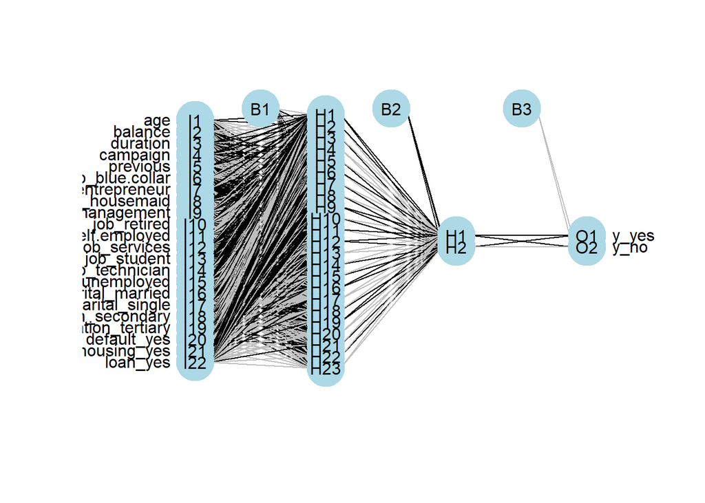